# Programming and Data Analysis with R

AS2019439

10/8/2022

**COVID-19 in Lebanon**

**1) INTRODUCTION**

Lebanon is a small, war-torn country on the east coast of the Mediterranean Sea. Located on fertile territory at the crossroads of three continents—Africa, Asia, and Europe.It is a valuable and highly desired territory. Throughout its history, it has been the stage for conflicts between local tribes-people and world powers.Lebanon gained full independence in 1943.

The presence of Palestinian refugees and guerrilla bases, and tensions between Christians and Muslims, have led to continuing political instability and warfare in recent decades. However, the Lebanese people have continued to survive in the face of repeated disruptions of their economy and day-to-day life. From 1975 until 1991, civil war ruined Lebanon. Since the early 1990s, the government has gradually regained power but there are still incidents of political violence, especially in the south near Israel.

Until recently, Lebanon was a war-torn nation. Much of the capital city of Beirut was in ruins. So was a great deal of the rest of the country. Rebuilding is now under way in order to address a lack of housing, as well as unreliable gas and water supplies.

In rural areas, farmhouses are made of stone or concrete with tile floors. They have only a few necessary pieces of furniture. A small wood-burning or kerosene stove is used for heat in the winter. Most rural houses have running water.

```
      date              province           country               lat
 Min.   :2020-01-22   Length:2652        Length:2652        Min.   :33.85
 1st Qu.:2020-08-29   Class :character   Class :character   1st Qu.:33.85
 Median :2021-04-07   Mode  :character   Mode  :character   Median :33.85
 Mean   :2021-04-07                                         Mean   :33.85
 3rd Qu.:2021-11-14                                         3rd Qu.:33.85
 Max.   :2022-06-23                                         Max.   :33.85

      long           type               cases              uid
 Min.   :35.86   Length:2652        Min.   :    0.0   Min.   :422
 1st Qu.:35.86   Class :character   1st Qu.:    0.0   1st Qu.:422
 Median :35.86   Mode  :character   Median :   14.0   Median :422
 Mean   :35.86                      Mean   :  623.9   Mean   :422
 3rd Qu.:35.86                      3rd Qu.:  625.0   3rd Qu.:422
 Max.   :35.86                      Max.   :12635.0   Max.   :422
                                    NA's   :1
     iso2               iso3               code3     combined_key
 Length:2652        Length:2652        Min.   :422   Length:2652
 Class :character   Class :character   1st Qu.:422   Class :character
 Mode  :character   Mode  :character   Median :422   Mode  :character
                                       Mean   :422
                                       3rd Qu.:422
                                       Max.   :422

   population      continent_name     continent_code
 Min.   :6825442   Length:2652        Length:2652
 1st Qu.:6825442   Class :character   Class :character
 Median :6825442   Mode  :character   Mode  :character
 Mean   :6825442
 3rd Qu.:6825442
 Max.   :6825442
```

```
[1] 2330
```

```
[1] 2652
```

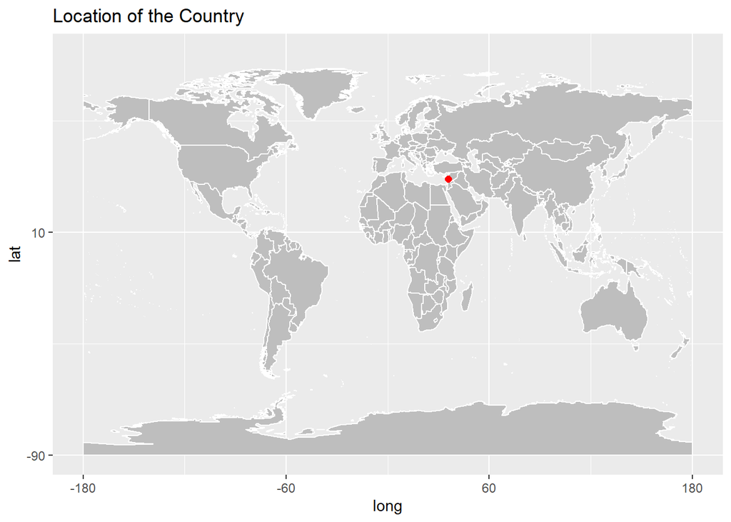

PRONUNCIATION: **leb-un-EEZ**

LOCATION: **Lebanon**

LANGUAGE: Arabic (official); **English; French**

RELIGION: Islam; Christianity; **Druze; Alawi; Baha’i**

**2) Exploratory Data Analysis**

Whole COVID-19 details in Lebanon

| date | province | country | lat | long | type | cases | uid | iso2 | iso3 | code3 | combined_key | population | continent_name | continent_code |
| --- | --- | --- | --- | --- | --- | --- | --- | --- | --- | --- | --- | --- | --- | --- |
| 2020-01-22 | NA | Lebanon | 33.8547 | 35.8623 | confirmed | 0 | 422 | LB | LBN | 422 | Lebanon | 6825442 | Asia | AS |
| 2020-01-23 | NA | Lebanon | 33.8547 | 35.8623 | confirmed | 0 | 422 | LB | LBN | 422 | Lebanon | 6825442 | Asia | AS |
| 2020-01-24 | NA | Lebanon | 33.8547 | 35.8623 | confirmed | 0 | 422 | LB | LBN | 422 | Lebanon | 6825442 | Asia | AS |
| 2020-01-25 | NA | Lebanon | 33.8547 | 35.8623 | confirmed | 0 | 422 | LB | LBN | 422 | Lebanon | 6825442 | Asia | AS |
| 2020-01-26 | NA | Lebanon | 33.8547 | 35.8623 | confirmed | 0 | 422 | LB | LBN | 422 | Lebanon | 6825442 | Asia | AS |

Confirmed COVID cases in Lebanon

| date | province | country | lat | long | type | cases | uid | iso2 | iso3 | code3 | combined_key | population | continent_name | continent_code |
| --- | --- | --- | --- | --- | --- | --- | --- | --- | --- | --- | --- | --- | --- | --- |
| 2020-01-22 | NA | Lebanon | 33.8547 | 35.8623 | confirmed | 0 | 422 | LB | LBN | 422 | Lebanon | 6825442 | Asia | AS |
| 2020-01-23 | NA | Lebanon | 33.8547 | 35.8623 | confirmed | 0 | 422 | LB | LBN | 422 | Lebanon | 6825442 | Asia | AS |
| 2020-01-24 | NA | Lebanon | 33.8547 | 35.8623 | confirmed | 0 | 422 | LB | LBN | 422 | Lebanon | 6825442 | Asia | AS |
| 2020-01-25 | NA | Lebanon | 33.8547 | 35.8623 | confirmed | 0 | 422 | LB | LBN | 422 | Lebanon | 6825442 | Asia | AS |
| 2020-01-26 | NA | Lebanon | 33.8547 | 35.8623 | confirmed | 0 | 422 | LB | LBN | 422 | Lebanon | 6825442 | Asia | AS |

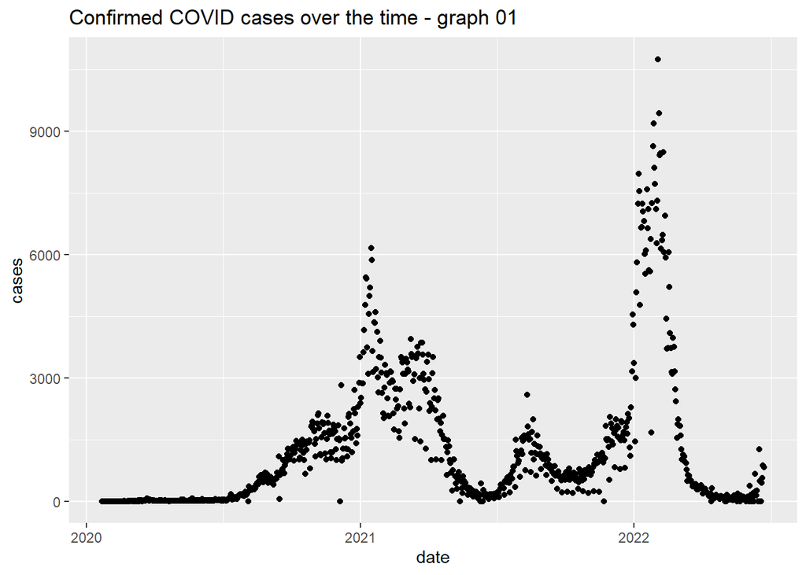

According to graph 1, we can see begging of the year 2021 and 2022 shows the higher number of confirmed cases compaired to the other time of the both years.

COVID-19 Death cases

| date | province | country | lat | long | type | cases | uid | iso2 | iso3 | code3 | combined_key | population | continent_name | continent_code |
| --- | --- | --- | --- | --- | --- | --- | --- | --- | --- | --- | --- | --- | --- | --- |
| 2020-01-22 | NA | Lebanon | 33.8547 | 35.8623 | death | 0 | 422 | LB | LBN | 422 | Lebanon | 6825442 | Asia | AS |
| 2020-01-23 | NA | Lebanon | 33.8547 | 35.8623 | death | 0 | 422 | LB | LBN | 422 | Lebanon | 6825442 | Asia | AS |
| 2020-01-24 | NA | Lebanon | 33.8547 | 35.8623 | death | 0 | 422 | LB | LBN | 422 | Lebanon | 6825442 | Asia | AS |
| 2020-01-25 | NA | Lebanon | 33.8547 | 35.8623 | death | 0 | 422 | LB | LBN | 422 | Lebanon | 6825442 | Asia | AS |
| 2020-01-26 | NA | Lebanon | 33.8547 | 35.8623 | death | 0 | 422 | LB | LBN | 422 | Lebanon | 6825442 | Asia | AS |

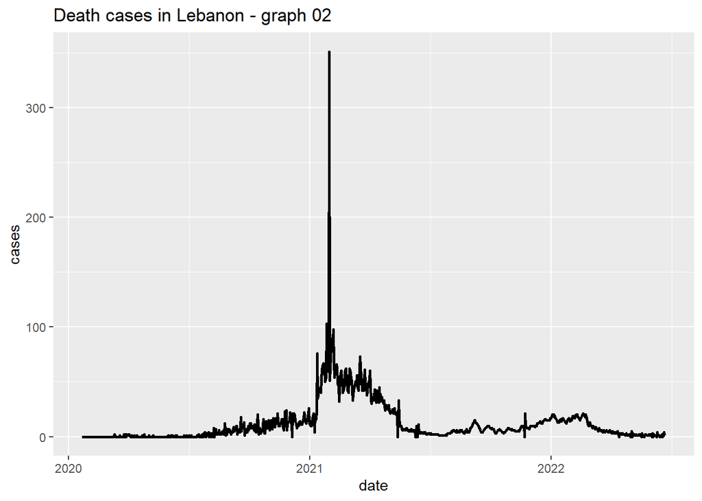

According to above chart, we can see there were higher number of deaths in begging of the 2021.Then gradually decreasing the number of deaths over the time.

COVID-19 Recover cases

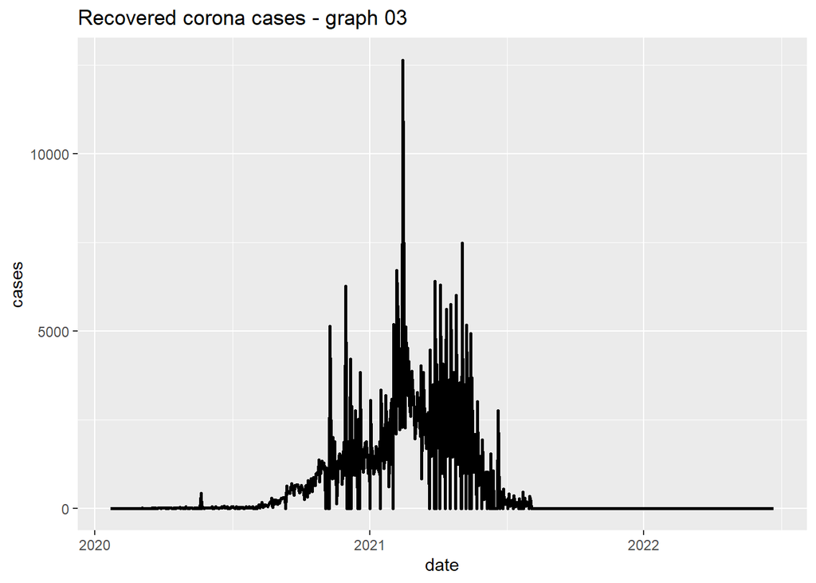

Higher number of recovered cases can be seen in the first half of the year 2021.And in some days there is no any recovered cases.

Line plot for total cases, total recoveries and total deaths

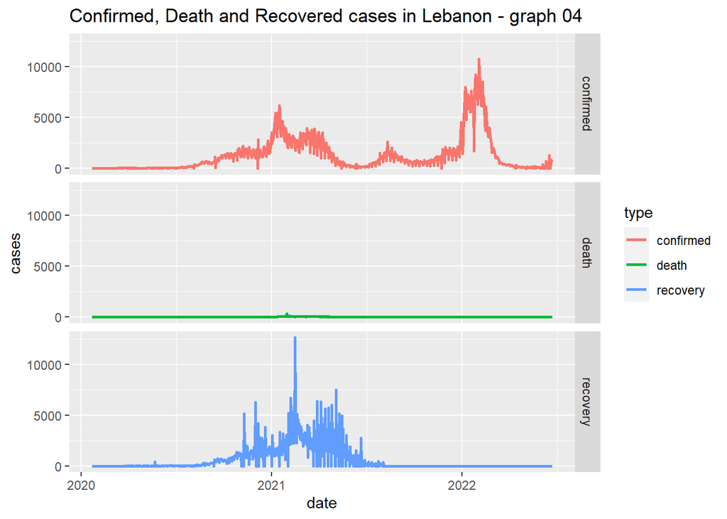

According to the graph 04 we can clearly see that in begging of the year 2021 there is a more deaths and recovered cases but more confirmed cases reported in after the year 2022.And also number of deaths are very low in Lebanon.

Compare Lebanon data set with Turkey and Armenia

```
      date              province           country               lat
 Min.   :2020-01-22   Length:2652        Length:2652        Min.   :38.96
 1st Qu.:2020-08-29   Class :character   Class :character   1st Qu.:38.96
 Median :2021-04-07   Mode  :character   Mode  :character   Median :38.96
 Mean   :2021-04-07                                         Mean   :38.96
 3rd Qu.:2021-11-14                                         3rd Qu.:38.96
 Max.   :2022-06-23                                         Max.   :38.96

      long           type               cases              uid
 Min.   :35.24   Length:2652        Min.   :      0   Min.   :792
 1st Qu.:35.24   Class :character   1st Qu.:     20   1st Qu.:792
 Median :35.24   Mode  :character   Median :    276   Median :792
 Mean   :35.24                      Mean   :   7794   Mean   :792
 3rd Qu.:35.24                      3rd Qu.:   5861   3rd Qu.:792
 Max.   :35.24                      Max.   :1123456   Max.   :792
                                    NA's   :1
     iso2               iso3               code3     combined_key
 Length:2652        Length:2652        Min.   :792   Length:2652
 Class :character   Class :character   1st Qu.:792   Class :character
 Mode  :character   Mode  :character   Median :792   Mode  :character
                                       Mean   :792
                                       3rd Qu.:792
                                       Max.   :792

   population       continent_name     continent_code
 Min.   :84339067   Length:2652        Length:2652
 1st Qu.:84339067   Class :character   Class :character
 Median :84339067   Mode  :character   Mode  :character
 Mean   :84339067
 3rd Qu.:84339067
 Max.   :84339067
```

```
[1] 2652
```

```
      date              province           country               lat
 Min.   :2020-01-22   Length:2652        Length:2652        Min.   :40.07
 1st Qu.:2020-08-29   Class :character   Class :character   1st Qu.:40.07
 Median :2021-04-07   Mode  :character   Mode  :character   Median :40.07
 Mean   :2021-04-07                                         Mean   :40.07
 3rd Qu.:2021-11-14                                         3rd Qu.:40.07
 Max.   :2022-06-23                                         Max.   :40.07

      long           type               cases             uid
 Min.   :45.04   Length:2652        Min.   :   0.0   Min.   :51
 1st Qu.:45.04   Class :character   1st Qu.:   1.0   1st Qu.:51
 Median :45.04   Mode  :character   Median :  22.0   Median :51
 Mean   :45.04                      Mean   : 246.1   Mean   :51
 3rd Qu.:45.04                      3rd Qu.: 262.8   3rd Qu.:51
 Max.   :45.04                      Max.   :8319.0   Max.   :51
                                    NA's   :2
     iso2               iso3               code3    combined_key
 Length:2652        Length:2652        Min.   :51   Length:2652
 Class :character   Class :character   1st Qu.:51   Class :character
 Mode  :character   Mode  :character   Median :51   Mode  :character
                                       Mean   :51
                                       3rd Qu.:51
                                       Max.   :51

   population      continent_name     continent_code
 Min.   :2963234   Length:2652        Length:2652
 1st Qu.:2963234   Class :character   Class :character
 Median :2963234   Mode  :character   Mode  :character
 Mean   :2963234
 3rd Qu.:2963234
 Max.   :2963234
```

```
[1] 1593 2330
```

Visualize the Confirm,death and recovery cases in Turkey and Armenia

[i] For Lebanon (graph 05)

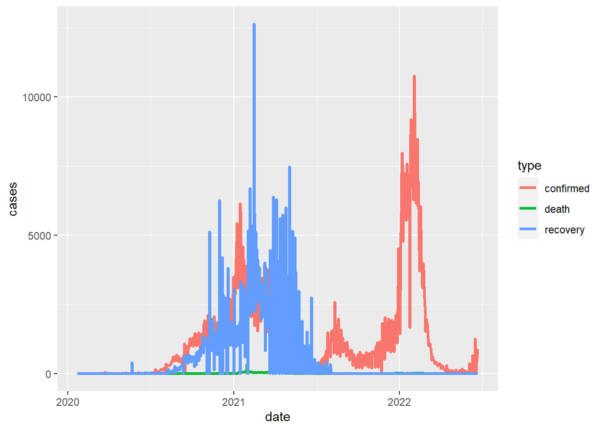

[ii] For Turkey (graph 06)

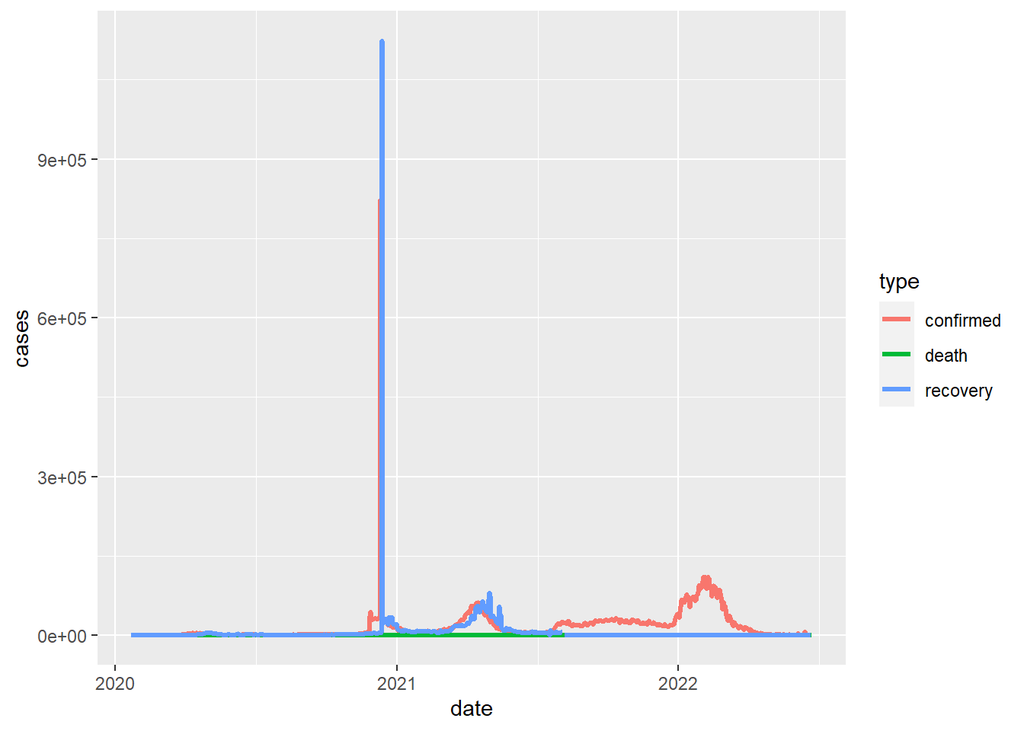

[iii] For Armenia (graph 07)

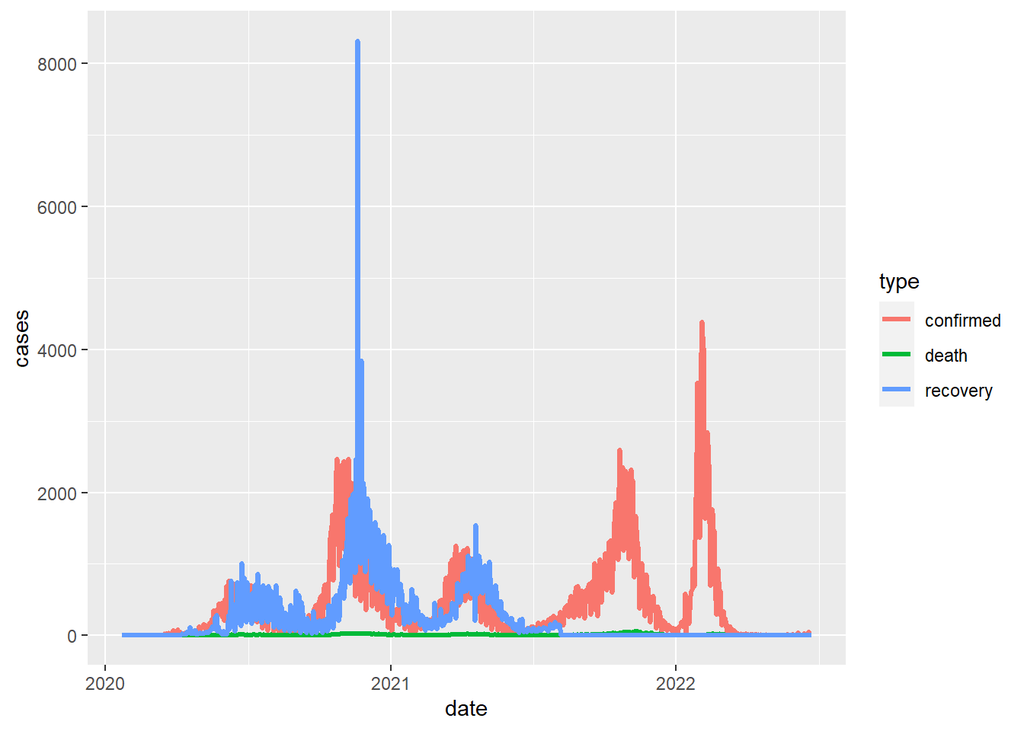

Comparison of confirmed,deaths and recover cases with Lebanon,Turkey and Armenia

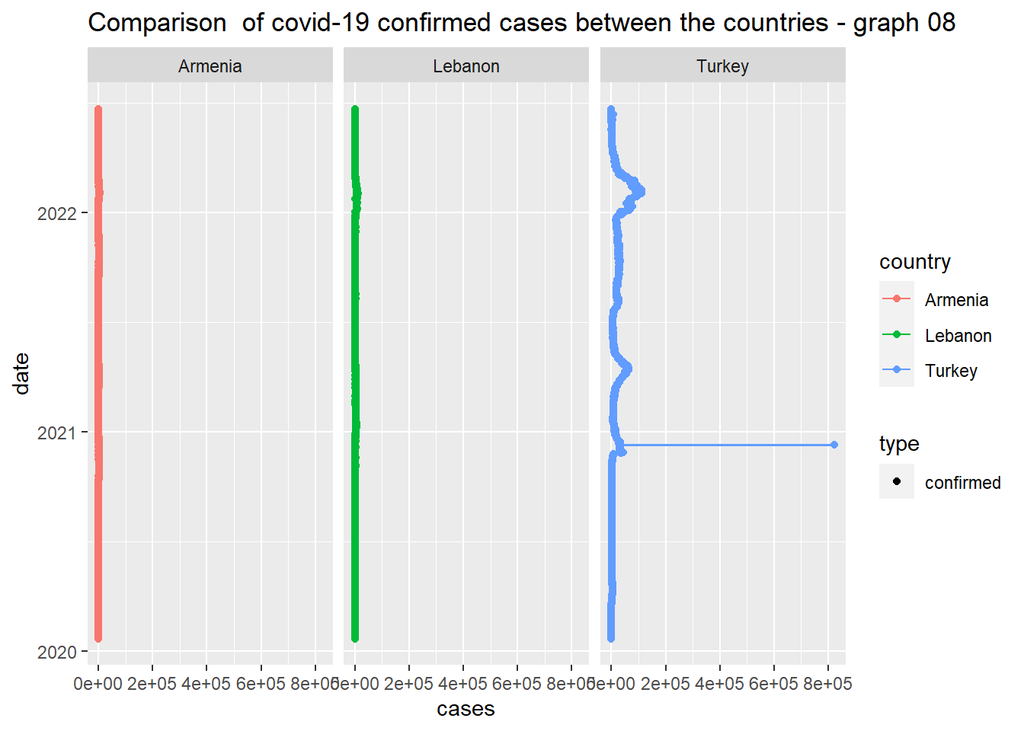

According to graph 8 we can see the highest covid-19 cases shown in the Turkey compared to other two countries.

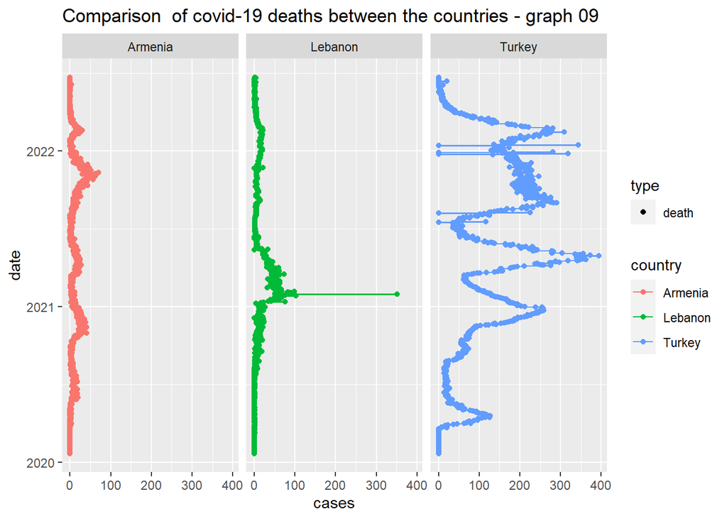

According to graph 09 Armenia has the lowest death cases ,but Turkey has the very high death cases over the past two years.

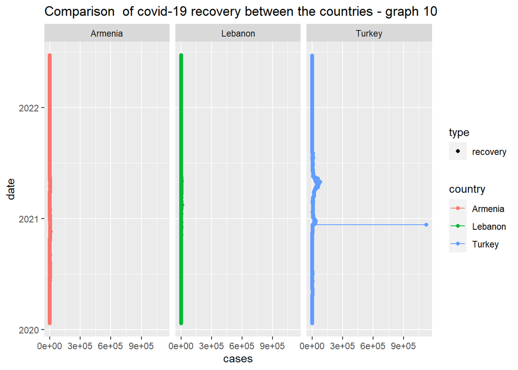

Recovery cases also high in the Turkey.

**3) Conclusions and Discussion**

**Conclusion**

In Lebanon, highest confirmed cases shown in the Beginning of the year 2022 and also first half of 2021 also shown the some some high confirmed cases.Beginning of the year 2021 shows the more than 300 death cases.Recovered cases also very high within first half of the year 2021.

When comparing Lebanon with Armenia and Turkey,Turkey shows the highest confirmed,death and recovery cases.

**Discussion**

In this analysis we take corona data set to analysis the behavior of deaths,confirmed and recovery cases in several countries. Before analysis,filter the data in main data set.After filtering the related data set convert the negative values into NA value. After that take the approximate values for that NA values,take the before and after row values of NA values and take their mean value as the approximate values of NA values(Mean imputation interpolation method).There were always error in this method but it is the more suitable method to get approximate value for NA value.Due to not availability of province wise data in Lebanon corona data set,the analysis couldn’t conduct province wise.And also due to low number of data we cant see any proper variation from the graph.

According to above analysis we can clearly see that number of death cases getting low but pandemic is not over yet, therefore prevention steps such as social distance, wear mask, cleaning hands often are some of steps that should be implemented in country.

**4) References**

https://www.everyculture.com/wc/Japan-to-Mali/Lebanese.html#:~:text=Lebanon%20is%20a%20small%2C%20war,valuable%20and%20highly%20desired%20territory.

WEBSITES ArabNet. [Online] Available http://www.arab.net/lebanon/lebanon_contents.html , 1998.

Embassy of Lebanon, Washington, D.C. [Online] Available http://www.erols.com/lebanon/ , 1998.

World Travel Guide, Lebanon. [Online] Available http://www.wtgonline.com/country/lb/gen.html , 1998.

Read more: https://www.everyculture.com/wc/Japan-to-Mali/Lebanese.html#ixzz7gU3QV2hO